# Mapping proteins to their genomic coordinates

Laurent Gatto - lg390@cam.ac.uk

## Introduction

The aim of this document is to document to mapping of proteins and the tandem mass spectrometry derived peptides they have been inferred from to genomic locations.

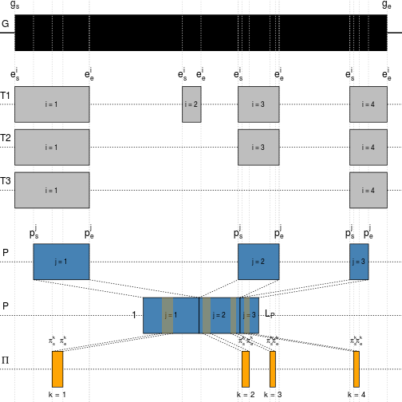

## Proteins and genome data

We will use a small object from `Pbase` to illustrate how to retrieve genome coordinates and map a protein back to genomic coordinates. In the remainder of this vignette, we will concentrate on a spectific protein, namely P00558.

```r
library("Pbase")
data(p)
p
```

```
## S4 class type     : Proteins
## Class version     : 0.1
## Created           : Wed Jul 16 02:58:33 2014
## Number of Proteins: 9
## Sequences:
##   [1] A4UGR9 [2] A6H8Y1 ... [8] P04075-2 [9] P60709
## Sequence features:
##   [1] DB [2] AccessionNumber ... [10] Comment [11] Filename
## Peptide features:
##   [1] DB [2] AccessionNumber ... [46] spectrumFile [47] databaseFile
```

```r
seqnames(p)
```

```
## [1] "A4UGR9"   "A6H8Y1"   "O43707"   "O75369"   "P00558"   "P02545"
## [7] "P04075"   "P04075-2" "P60709"
```

```r
dat <- data.frame(i = 1:length(p),
                  npeps = elementLengths(pfeatures(p)),
                  protln = width(aa(p)))
dat
```

```
##          i npeps protln
## A4UGR9   1    36   3374
## A6H8Y1   2    23   2624
## O43707   3     6    911
## O75369   4    13   2602
## P00558   5     5    417
## P02545   6    12    664
## P04075   7    21    364
## P04075-2 8    20    418
## P60709   9     1    375
```

```r
sp <- seqnames(p)[5]
```

### Querying with `biomaRt`

The input information consists of a UniProt identifier and a set of peptides positions along the protein. The first step is to map the protein accession number to a gene identifier (here, we will use Ensembl) and to obtain genome coordinates.

Multiple solutiona are offered to use. Below, we use the `biomaRt` Bioconductor package.

```r
library("biomaRt")
ens <- useMart("ensembl", "hsapiens_gene_ensembl")

bm <- select(ens, keys = sp,
             keytype = "uniprot_swissprot_accession",
             columns = c(
                 "ensembl_gene_id",
                 "ensembl_transcript_id",
                 "ensembl_peptide_id",
                 "ensembl_exon_id",
                 "description",
                 "chromosome_name",
                 "strand",
                 "exon_chrom_start",
                 "exon_chrom_end",
                 "5_utr_start",
                 "5_utr_end",
                 "3_utr_start",
                 "3_utr_end",
                 "start_position",
                 "end_position"))

bm
```

```
##    ensembl_gene_id ensembl_transcript_id ensembl_peptide_id
## 1  ENSG00000102144       ENST00000373316    ENSP00000362413
## 2  ENSG00000102144       ENST00000373316    ENSP00000362413
## 3  ENSG00000102144       ENST00000373316    ENSP00000362413
## 4  ENSG00000102144       ENST00000373316    ENSP00000362413
## 5  ENSG00000102144       ENST00000373316    ENSP00000362413
## 6  ENSG00000102144       ENST00000373316    ENSP00000362413
## 7  ENSG00000102144       ENST00000373316    ENSP00000362413
## 8  ENSG00000102144       ENST00000373316    ENSP00000362413
## 9  ENSG00000102144       ENST00000373316    ENSP00000362413
## 10 ENSG00000102144       ENST00000373316    ENSP00000362413
## 11 ENSG00000102144       ENST00000373316    ENSP00000362413
## 12 ENSG00000269666       ENST00000597340    ENSP00000472461
## 13 ENSG00000269666       ENST00000597340    ENSP00000472461
## 14 ENSG00000269666       ENST00000597340    ENSP00000472461
```

[output cut: 77 more lines]

We will only consider the gene located on the X chromosome and ignore the [sequence](http://www.ncbi.nlm.nih.gov/projects/genome/assembly/grc/info/patches.shtml) [patch](http://www.ncbi.nlm.nih.gov/nuccore/NW_003871101.3?report=genbank) and conveniently store the transcript and protein identifiers for later use.

```r
bm <- bm[bm$chromosome_name == "X", ]
tr <- unique(bm$ensembl_transcript_id)
pr <- unique(bm$ensembl_peptide_id)
```

### Genome visualisation with `Gviz`

While the above defines all necessary genomic coordinates, and as we will make use of the `Gviz` plotting infrastructure, it is more straightforward to fetch the above information via `biomaRt` using specialised `Gviz` infrastructure.

```r
library("Gviz")
options(ucscChromosomeNames=FALSE)

bmTrack <- BiomartGeneRegionTrack(start = min(bm$start_position),
                                  end = max(bm$end_position),
                                  chromosome = "chrX",
                                  genome = "hg19")

## see also the filters param and getBM to
## filter on biotype == "protein_coding"

bmTracks <- split(bmTrack, transcript(bmTrack))

grTrack <- bmTracks[[which(names(bmTracks) == tr)]]
names(grTrack) <- tr
```

We can convince ourselves that the manual retrieved data in `bm` and the data in the `BiomartRegionTrack` subsequently subset into a `GeneRegionTrack` match.

```r
as(grTrack, "data.frame")
```

```
##    X.seqnames  X.start    X.end X.width X.strand      X.feature
## 1           X 77359671 77359837     167        +           utr5
## 2           X 77359838 77359902      65        + protein_coding
## 3           X 77365364 77365414      51        + protein_coding
## 4           X 77369241 77369396     156        + protein_coding
## 5           X 77369513 77369657     145        + protein_coding
## 6           X 77372809 77372912     104        + protein_coding
## 7           X 77373548 77373667     120        + protein_coding
## 8           X 77378332 77378446     115        + protein_coding
## 9           X 77378692 77378871     180        + protein_coding
## 10          X 77380371 77380548     178        + protein_coding
## 11          X 77380824 77380922      99        + protein_coding
## 12          X 77381287 77381327      41        + protein_coding
## 13          X 77381328 77384793    3466        +           utr3
##             X.gene          X.exon    X.transcript X.symbol X.rank X.phase
## 1  ENSG00000102144 ENSE00001600900 ENST00000373316     PGK1      1      -1
## 2  ENSG00000102144 ENSE00001600900 ENST00000373316     PGK1      1      -1
## 3  ENSG00000102144 ENSE00003506377 ENST00000373316     PGK1      2       2
## 4  ENSG00000102144 ENSE00003502842 ENST00000373316     PGK1      3       2
## 5  ENSG00000102144 ENSE00003512377 ENST00000373316     PGK1      4       2
## 6  ENSG00000102144 ENSE00003581136 ENST00000373316     PGK1      5       0
## 7  ENSG00000102144 ENSE00003597777 ENST00000373316     PGK1      6       2
## 8  ENSG00000102144 ENSE00000672997 ENST00000373316     PGK1      7       2
## 9  ENSG00000102144 ENSE00000672996 ENST00000373316     PGK1      8       0
## 10 ENSG00000102144 ENSE00000672995 ENST00000373316     PGK1      9       0
## 11 ENSG00000102144 ENSE00000672994 ENST00000373316     PGK1     10       1
## 12 ENSG00000102144 ENSE00001948816 ENST00000373316     PGK1     11       0
## 13 ENSG00000102144 ENSE00001948816 ENST00000373316     PGK1     11      -1
```

Below, we create additional ideogram and axis tracks and produce a visualisation of our genomic coordinates of interest.

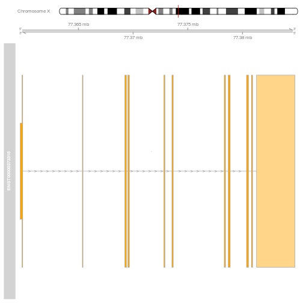

```r
ideoTrack <- IdeogramTrack(genome = "hg19",
                           chromosome = "chrX")
axisTrack <- GenomeAxisTrack()
seqlevels(ranges(grTrack)) <-
    chromosome(grTrack) <-
        chromosome(ideoTrack)
plotTracks(list(ideoTrack, axisTrack, grTrack),
           add53 = TRUE, add35 = TRUE)
```

### Using `TranscriptDb` instances

Finally, on could also use `TranscriptDb` objects to create the `GeneRegionTrack`. Below, we use the UCSC annotation (which is directly available from Bioconductor; Ensembl TranscriptDb instances could be generated manually - **TODO** document this) to extract our regions of interest.

```r
library("TxDb.Hsapiens.UCSC.hg19.knownGene")
txdb <- TxDb.Hsapiens.UCSC.hg19.knownGene
txTr <- GeneRegionTrack(txdb, chromosome = "chrX",
                        start = bm$start_position[1],
                        end = bm$end_position[1])

head(as(txTr, "data.frame"))
```

```
##   X.seqnames  X.start    X.end X.width X.strand X.feature    X.id
## 1       chrX 77359666 77359837     172        +      utr5 unknown
## 2       chrX 77359838 77359902      65        +       CDS unknown
## 3       chrX 77361859 77362168     310        +      utr5 unknown
## 4       chrX 77365364 77365382      19        +      utr5 unknown
## 5       chrX 77365364 77365414      51        +       CDS unknown
## 6       chrX 77365383 77365414      32        +       CDS unknown
##         X.exon X.transcript X.gene   X.symbol X.density
## 1 uc004ecz.4_1   uc004ecz.4   5230 uc004ecz.4         1
## 2 uc004ecz.4_1   uc004ecz.4   5230 uc004ecz.4         1
## 3 uc011mqq.2_1   uc011mqq.2   5230 uc011mqq.2         1
## 4 uc011mqq.2_2   uc011mqq.2   5230 uc011mqq.2         1
## 5 uc004ecz.4_2   uc004ecz.4   5230 uc004ecz.4         1
## 6 uc011mqq.2_2   uc011mqq.2   5230 uc011mqq.2         1
```

## Peptide features

The peptides that have been experimentally observed are available as ranges (coordinates) along the protein sequences. For example, below, we see 5 peptides (ELNYFAKALESPER, DLMSKAEK, QIVWNGPVGVFEWEAFAR, FHVEEEGKGKDASGNK, GTKALMDEVVK) have been identified for our protein of interest P00558.

```r
pp <- p[sp]
pranges(pp)
```

```
## IRangesList of length 1
## $P00558
## IRanges of length 5
##     start end width  names
## [1]   193 206    14 P00558
## [2]   268 275     8 P00558
## [3]   333 350    18 P00558
## [4]   124 139    16 P00558
## [5]   351 361    11 P00558
```

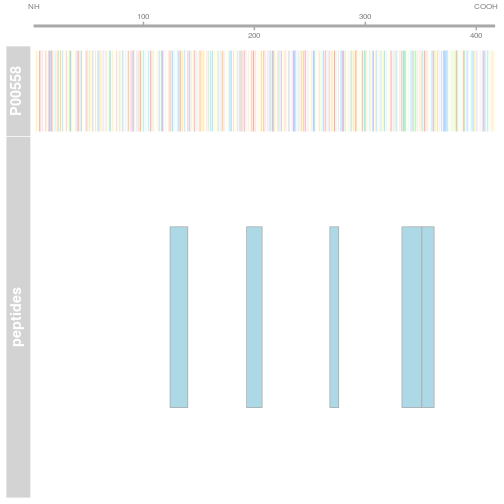

```r
plot(pp)
```

The aim of this document is to document the mapping of peptides, i.e. ranges along a protein sequence to ranges along the genome reference. In other words, our aim is the convert protein coordinates to genome coordinates.

## Mapping peptides back to the genome

Additional features of interest (in our case peptides) can be added to the genomic visualisation using dedicated annotation tracks, that can be constructed as shown below.

### Comparing protein and translated DNA sequences

The first check that we want to implement is to verify that we can regenerate the protein amino acid sequence from the genome regions that we have extracted. We start by subsetting only the actual protein coding regions, i.e ignoring the 5' and 3' untranslated regions of our Genome Region track.

```r
(prng <- ranges(grTrack[feature(grTrack) == "protein_coding",]))
```

```
## GRanges with 11 ranges and 7 metadata columns:
##        seqnames               ranges strand   |        feature
##           <Rle>            <IRanges>  <Rle>   |    <character>
##    [1]     chrX [77359838, 77359902]      +   | protein_coding
##    [2]     chrX [77365364, 77365414]      +   | protein_coding
##    [3]     chrX [77369241, 77369396]      +   | protein_coding
##    [4]     chrX [77369513, 77369657]      +   | protein_coding
##    [5]     chrX [77372809, 77372912]      +   | protein_coding
##    ...      ...                  ...    ... ...            ...
##    [7]     chrX [77378332, 77378446]      +   | protein_coding
##    [8]     chrX [77378692, 77378871]      +   | protein_coding
##    [9]     chrX [77380371, 77380548]      +   | protein_coding
##   [10]     chrX [77380824, 77380922]      +   | protein_coding
##   [11]     chrX [77381287, 77381327]      +   | protein_coding
##                   gene            exon      transcript      symbol
##            <character>     <character>     <character> <character>
##    [1] ENSG00000102144 ENSE00001600900 ENST00000373316        PGK1
##    [2] ENSG00000102144 ENSE00003506377 ENST00000373316        PGK1
##    [3] ENSG00000102144 ENSE00003502842 ENST00000373316        PGK1
##    [4] ENSG00000102144 ENSE00003512377 ENST00000373316        PGK1
##    [5] ENSG00000102144 ENSE00003581136 ENST00000373316        PGK1
##    ...             ...             ...             ...         ...
##    [7] ENSG00000102144 ENSE00000672997 ENST00000373316        PGK1
##    [8] ENSG00000102144 ENSE00000672996 ENST00000373316        PGK1
##    [9] ENSG00000102144 ENSE00000672995 ENST00000373316        PGK1
##   [10] ENSG00000102144 ENSE00000672994 ENST00000373316        PGK1
##   [11] ENSG00000102144 ENSE00001948816 ENST00000373316        PGK1
##             rank     phase
##        <numeric> <integer>
##    [1]         1        -1
##    [2]         2         2
##    [3]         3         2
##    [4]         4         2
##    [5]         5         0
##    ...       ...       ...
##    [7]         7         2
##    [8]         8         0
##    [9]         9         0
##   [10]        10         1
##   [11]        11         0
##   ---
##   seqlengths:
##    chrX
##      NA
```

```r
library("Biostrings")
chrx <- readDNAStringSet("./Homo_sapiens.GRCh37.75.dna.chromosome.X.fa.gz")
seq <- extractAt(chrx[[1]], ranges(prng))
pptr <- translate(unlist(seq))
```

It is also possible to use readily package genomes to do this. Above, we have use the `TxDb.Hsapiens.UCSC.hg19.knownGene` package defining transcripts. There is a similar package for the human UCSC genome build, namely `BSgenome.Hsapiens.UCSC.hg19`. However, as we have focused on Ensembl data annotation, we will first need to convert our Ensembl transcript (or protein) identifier ENST00000373316 (ENSP00000362413) into the UCSC equivalent. (**TODO** Use also `Homo.sapiens` annotation package.)

```r
ucsc <- select(ens, key = pr,
               keytype = "ensembl_peptide_id",
               columns = "ucsc")
ucsc
```

```
##         ucsc
## 1 uc004ecz.4
```

```r
library("BSgenome.Hsapiens.UCSC.hg19")
prng2 <- ranges(txTr[transcript(txTr) %in% ucsc])
prng2 <- prng2[prng2$feature == "CDS"]

seq <- getSeq(BSgenome.Hsapiens.UCSC.hg19, prng2)
pptr <- translate(unlist(seq))
## remove stop codon
pptr <- pptr[1:417]
```

```r
writePairwiseAlignments(pairwiseAlignment(pp[[1]], pptr))
```

```
## ########################################
## # Program: Biostrings (version 2.33.12), a Bioconductor package
## # Rundate: Thu Jul 24 01:36:49 2014
## ########################################
## #=======================================
## #
## # Aligned_sequences: 2
## # 1: P1
## # 2: S1
## # Matrix: NA
## # Gap_penalty: 14.0
## # Extend_penalty: 4.0
## #
## # Length: 417
## # Identity:     417/417 (100.0%)
## # Similarity:    NA/417 (NA%)
## # Gaps:           0/417 (0.0%)
## # Score: 1795
## #
## #
## #=======================================
##
## P1                 1 MSLSNKLTLDKLDVKGKRVVMRVDFNVPMKNNQITNNQRIKAAVPSIKFC     50
##                      ||||||||||||||||||||||||||||||||||||||||||||||||||
## S1                 1 MSLSNKLTLDKLDVKGKRVVMRVDFNVPMKNNQITNNQRIKAAVPSIKFC     50
##
## P1                51 LDNGAKSVVLMSHLGRPDGVPMPDKYSLEPVAVELKSLLGKDVLFLKDCV    100
##                      ||||||||||||||||||||||||||||||||||||||||||||||||||
## S1                51 LDNGAKSVVLMSHLGRPDGVPMPDKYSLEPVAVELKSLLGKDVLFLKDCV    100
##
## P1               101 GPEVEKACANPAAGSVILLENLRFHVEEEGKGKDASGNKVKAEPAKIEAF    150
##                      ||||||||||||||||||||||||||||||||||||||||||||||||||
## S1               101 GPEVEKACANPAAGSVILLENLRFHVEEEGKGKDASGNKVKAEPAKIEAF    150
##
## P1               151 RASLSKLGDVYVNDAFGTAHRAHSSMVGVNLPQKAGGFLMKKELNYFAKA    200
##                      ||||||||||||||||||||||||||||||||||||||||||||||||||
## S1               151 RASLSKLGDVYVNDAFGTAHRAHSSMVGVNLPQKAGGFLMKKELNYFAKA    200
##
## P1               201 LESPERPFLAILGGAKVADKIQLINNMLDKVNEMIIGGGMAFTFLKVLNN    250
##                      ||||||||||||||||||||||||||||||||||||||||||||||||||
## S1               201 LESPERPFLAILGGAKVADKIQLINNMLDKVNEMIIGGGMAFTFLKVLNN    250
##
## P1               251 MEIGTSLFDEEGAKIVKDLMSKAEKNGVKITLPVDFVTADKFDENAKTGQ    300
##                      ||||||||||||||||||||||||||||||||||||||||||||||||||
## S1               251 MEIGTSLFDEEGAKIVKDLMSKAEKNGVKITLPVDFVTADKFDENAKTGQ    300
##
## P1               301 ATVASGIPAGWMGLDCGPESSKKYAEAVTRAKQIVWNGPVGVFEWEAFAR    350
##                      ||||||||||||||||||||||||||||||||||||||||||||||||||
## S1               301 ATVASGIPAGWMGLDCGPESSKKYAEAVTRAKQIVWNGPVGVFEWEAFAR    350
##
## P1               351 GTKALMDEVVKATSRGCITIIGGGDTATCCAKWNTEDKVSHVSTGGGASL    400
##                      ||||||||||||||||||||||||||||||||||||||||||||||||||
## S1               351 GTKALMDEVVKATSRGCITIIGGGDTATCCAKWNTEDKVSHVSTGGGASL    400
##
## P1               401 ELLEGKVLPGVDALSNI    417
##                      |||||||||||||||||
## S1               401 ELLEGKVLPGVDALSNI    417
##
##
## #---------------------------------------
## #---------------------------------------
```

### Calculating new coordinates

To calculate the genomic coordinates of peptides we

1) Calculate the contiguous exon coordinates on the cDNA sequence `prex`.

2) Calculate the peptide corrdinates on the cDNA sequence `peprgn2` from the original peptide ranges along the protein sequence.

3) We calculate the indices of the exons in which all the peptides start and end on the cDNA sequence `start_ex` and `end_ex`.

4) We infer the coordinates on the genome from the actual peptide starting/ending position and exon index on the cDNA sequence, the exons coordinates on the cDNA sequences and the matching exons coordinates on the genome and store these in an `IRanges` object.

```r
## exons ranges along the protein
j <- cumsum(width(seq))
i <- cumsum(c(1, width(seq)))[1:length(j)]
prex <- IRanges(start = i, end = j)

peprng <- pranges(pp)[[1]]
## peptide positions on cdna
peprng2 <- IRanges(start = 1 + (start(peprng)-1) * 3,
                   width = width(peprng) * 3)

## find exon and position in prex
start_ex <- subjectHits(findOverlaps(start(peprng2), prex))
end_ex <- subjectHits(findOverlaps(end(peprng2), prex))

getPos <- function(p, i, prtex = prex, nclex = prng2) {
    ## position in cdna
    ## exon index
    start(prng2[i]) + (p - start(prtex[i]))
}

peptides_on_genome <- IRanges(start = getPos(start(peprng2), start_ex),
                              end = getPos(end(peprng2), end_ex))
```

### Plotting

Based on the new peptide genomic coordinates, it is now straightforward to create a new `AnnotationTrack` and add it the the track visualisation.

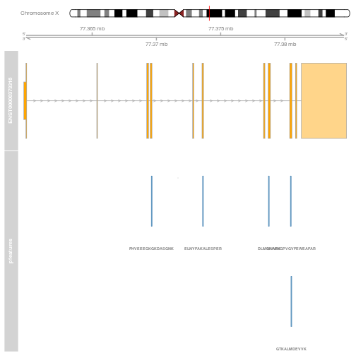

```r
pepTr <- AnnotationTrack(start = start(peptides_on_genome),
                         end = end(peptides_on_genome),
                         chr = "chrX", genome = "hg19",
                         strand = "*",
                         id = pcols(pp)[[1]]$pepseq,
                         name = "pfeatures",
                         col = "steelblue")


plotTracks(list(ideoTrack, axisTrack, grTrack, pepTr),
           groupAnnotation = "id",
           just.group = "below",
           fontsize.group = 9,
           add53 = TRUE, add35 = TRUE)
```

### DetailsAnnotationTrack

Finally, we customise the figure by adding a track with the \(MS^2\) spectra. The raw data used to search the protein database an create `p` are available as an `MSnExp` object.

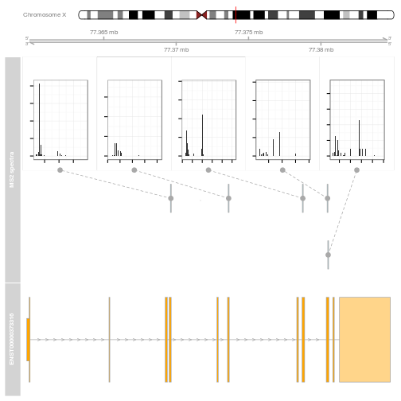

```r
data(pms)

library("ggplot2")
details <- function(identifier, ...) {
    p <- plot(pms[[as.numeric(identifier)]], full=TRUE, plot=FALSE) + ggtitle("")
    p <- p + theme_bw() + theme(axis.text.y = element_blank(),
                                axis.text.x = element_blank()) +
                                labs(x = NULL, y = NULL)

    print(p, newpage=FALSE)
}

deTrack <- AnnotationTrack(start = start(peptides_on_genome),
                           end = end(peptides_on_genome),
                           genome = "hg19", chromosom = "chrX",
                           id = pcols(pp)[[1]]$acquisitionnum,
                           name = "MS2 spectra",
                           stacking = "squish", fun = details)

plotTracks(list(ideoTrack, axisTrack, deTrack, grTrack),
           add53 = TRUE, add35 = TRUE)
```

**TODO** Check spectra. Describe how data tracks can be used to overlay additional information, such as quantitation data, identification scores, coverage, …

```
## R Under development (unstable) (2014-04-10 r65396)
## Platform: x86_64-unknown-linux-gnu (64-bit)
##
## locale:
##  [1] LC_CTYPE=en_GB.UTF-8       LC_NUMERIC=C
##  [3] LC_TIME=en_GB.UTF-8        LC_COLLATE=en_GB.UTF-8
##  [5] LC_MONETARY=en_GB.UTF-8    LC_MESSAGES=en_GB.UTF-8
##  [7] LC_PAPER=en_GB.UTF-8       LC_NAME=C
##  [9] LC_ADDRESS=C               LC_TELEPHONE=C
## [11] LC_MEASUREMENT=en_GB.UTF-8 LC_IDENTIFICATION=C
##
## attached base packages:
## [1] parallel  grid      methods   stats     graphics  grDevices utils
## [8] datasets  base
##
```

[output cut: 56 more lines]